##### Análise Exploratória de Dados

# Saúde Psicológica e Bem-estar

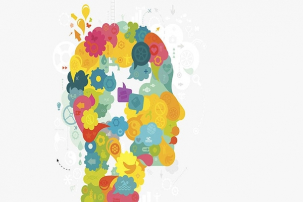

###### **Grupo 9**

###### Camila Tavares de Sousa, nº 111017, CDA1

###### Carolina Vitória Prior dos Santos Brunheta, nº 110888, CDA1

###### Marco Delgado Esperança, nº 110451, CDB1

###### Miguel Duarte Aguilar das Neves Correia, nº 110786, CDA1

###### 2 de abril de 2023

### Índice

**1. Sumário executivo**

**2. Introdução**

**3. Análise de resultados**

**4. Conclusão**

### Introdução

A preocupação com a saúde psicológica e bem-estar dos indivíduos é importante, por isso, o estudo e compreensão desta área é crucial para acompanhar a atual situação da saúde mental e bem-estar da população. A saúde psicológica e bem-estar abrangem diversos aspetos, tais como emoções, comportamentos e relações sociais.

Foi realizado um estudo por questionário sobre a temática “Saúde Psicológica e Bem-estar” em crianças e adolescentes em idade escolar, promovido pelo Ministério da Educação em 2022, após o período de pandemia Covid-19. O objetivo deste estudo é o diagnóstico e conhecimento do panorama da saúde psicológica e bem-estar dos alunos em diferentes regiões de Portugal. Os dados disponibilizados referem-se a um excerto das respostas dos alunos (ou dos seus educadores) ao questionário aplicado, relativamente a algumas das perguntas enquadradas nos objetivos definidos e alguma informação de caracterização das crianças e jovens.

Com a realização do caso prático, pretende-se a preparação e organização do conjunto de dados e correspondente análise descritiva, em função do contexto e objetivos definidos. Para tal, utilizaremos as competências adquiridas nesta unidade curricular, empregando as ferramentas supracitadas para conduzir a análise exploratória dos dados, executando as seguintes tarefas:

- Preparação e organização do conjunto de dados;
- Realização de análise descritiva;
- Representação gráfica dos resultados;
- Discussão dos resultados obtidos e interpretação dos mesmos em função dos objetivos definidos.

### Análise de resultados

Com o objetivo de diagnosticar e compreender a situação da saúde mental e bem-estar de crianças e adolescentes em idade escolar (do pré-escolar ao 12º ano) em diferentes regiões de Portugal, após o período de pandemia da Covid-19, foram realizadas algumas perguntas que se referem a aspectos de saúde psicológica e bem-estar, bem como informações de caracterização dos alunos e suas respostas, a fim de obter um panorama da situação.

Após o tratamento de dados para uma melhor recolha e compreensão da informação, é iniciada a fase de os descrever e sumarizar (análise descritiva). Através da análise dos dados é possível obter informações relevantes, normalmente expressadas percentualmente.

O inquérito foi realizado por meio de questionário e obteve respostas de 195 pessoas, das quais 95 eram do sexo feminino (48.7%) e 100 do sexo masculino (51.3%) (ver Tabela 1). Todos os participantes são da região do Algarve e as crianças envolvidas estão matriculadas no 1º ciclo.

Tabela 1 - Tabela de frequências do género

|  | Número de respostas | Percentagem |
| --- | --- | --- |
| Feminino | 95 | 48.7% |
| Masculino | 100 | 51.3% |

Em relação à sensibilidade relativamente aos outros, podemos constatar tal como se apresenta na tabela de seguida que a grande maioria das crianças demostra ter muita sensibilidade aos outros (“É muito verdade”), com apenas 5.2% a não demonstrarem essa sensibilidade.

Tabela 2 - Tabela de frequências da sensibilidade

|  | Número de Respostas | Percentagem |
| --- | --- | --- |
| Não é verdade | 10 | 5.2% |
| É pouco verdade | 31 | 16.1% |
| É muito verdade | 151 | 78.6% |

De seguida, apresenta-se o gráfico de barras relativamente ao nível de concordância da sensibilidade.

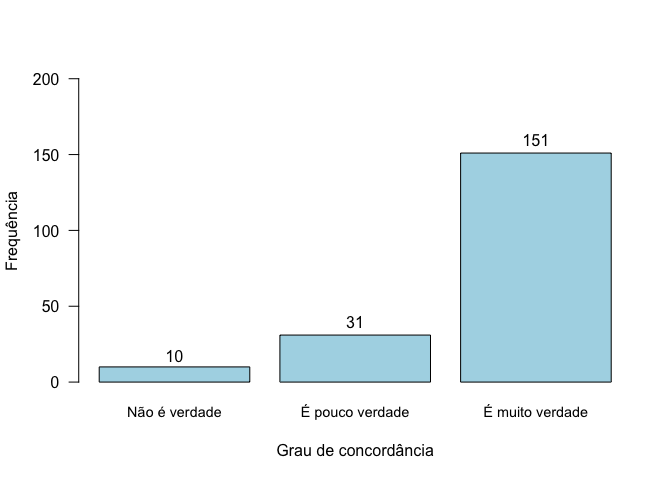

Relativamente ao isolamento social, um dos fatores mais importantes a analisar num contexto pós-pandémico, verifica-se que, na amostra considerada, a maioria das crianças demonstrou falta do contacto pessoal, visível pela grande maioria delas não ser verdade que tenham algum nível de isolamento social (78.6%).

Tabela 3 - Tabela de frequências do isolamento

|  | Número de respostas | Percentagem |
| --- | --- | --- |
| Não é verdade | 151 | 78.6% |
| É pouco verdade | 33 | 17.2% |
| É muito verdade | 8 | 4.2% |

Apresenta-se o gráfico de barras correspondente ao grau de concordância do isolamento.

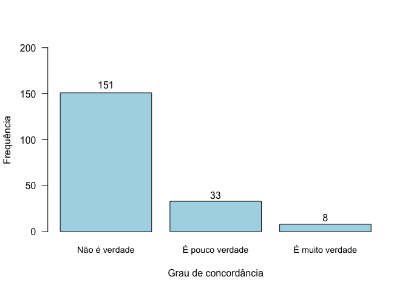

Ainda relativamente ao isolamento social, decidiu fazer-se uma análise para perceber se o nível de isolamento social varia consoante o género.

Tabela 4 - Tabela de frequências do isolamento por género

|  | Não é verdade | É pouco verdade | É muito verdade |
| --- | --- | --- | --- |
| Feminino | 84 | 9 | 1 |
| Masculino | 66 | 24 | 7 |

|  | Não é verdade | É pouco verdade | É muito verdade |
| --- | --- | --- | --- |
| Feminino | 44% | 4.7% | 0.5% |
| Masculino | 34.6% | 12.6% | 3.7% |

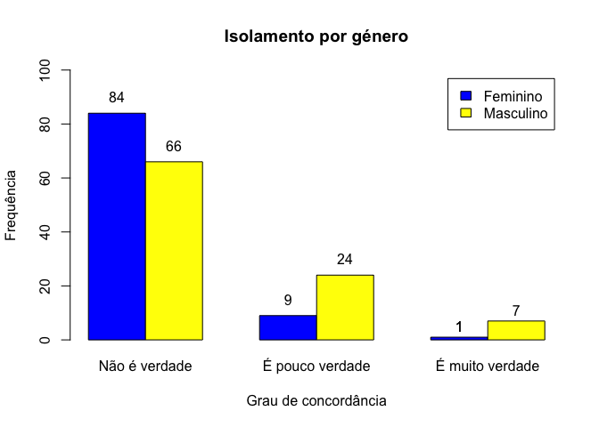

Apesar de a grande maioria das crianças não se isolarem, aqueles que demonstram maior nível de isolamento são os rapazes (31) face às raparigas (10).

Já no que diz respeito à agressividade, como pode ser verificado na tabela a seguir, a maioria das crianças não parece apresentar qualquer tipo de agressividade (65.8%). Isso significa que a maioria das crianças não demonstra comportamentos agressivos.

Tabela 5 - Tabela de frequências da agressividade

|  | Número de respostas | Percentagem |
| --- | --- | --- |
| Não é verdade | 129 | 65.8% |
| É pouco verdade | 59 | 30.1% |
| É muito verdade | 8 | 4.1% |

A pandemia de COVID-19 criou, em todos os estudantes, a necessidade de realizar as atividades escolares online. Assim, as crianças do primeiro ciclo passaram a ter ainda mais contacto com dispositivos eletrónicos, para além daquele que, certamente, já teriam num contexto de lazer, uma vez que vivemos numa era digital em que o acesso às tecnologias é cada vez mais precoce. Desta forma, achamos pertinente analisar, se, mesmo após a retoma do ensino presencial, as crianças continuam a estar expostas a ecrãs durante muitas horas, diariamente.

Tabela 6 - Tabela de frequências do tempo passado num ecrã (número de horas)

|  | Número de respostas | Percentagem |
| --- | --- | --- |
| 0 | 4 | 2% |
| 1 | 128 | 65.3% |
| 2 | 54 | 27.6% |
| 3 | 9 | 4.6% |
| 4 | 1 | 0.5% |

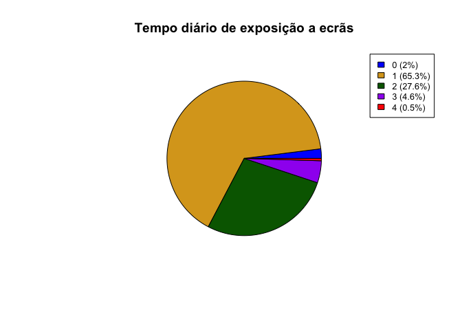

A partir do gráfico, podemos observar que a maioria das crianças (65.3%) passam apenas 1 hora por dia em frente a um ecrã, enquanto uma parcela significativa (27.6%) passa 2 horas por dia. A quantidade de crianças que passam 3 horas ou mais por dia em frente a um ecrã é relativamente pequena, com apenas 4.6% das crianças passando 3 horas e 0.5% passando 4 horas por dia. Um pequeno número de crianças (2%) não passa nenhuma hora por dia em frente a um ecrã.

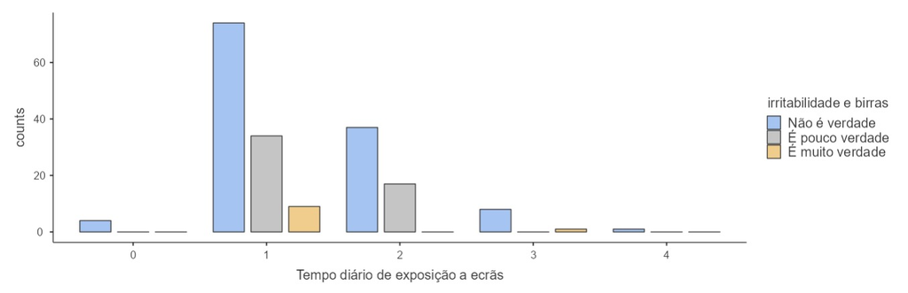

Analisando o gráfico, verifica-se que há uma subida significativa da irritabilidade/birras de 0h para 1h do tempo de ecrã, contudo a partir das 2h esse nível começa, genericamente, gradualmente a descer, o que pode ser fruto de fraca interação social por elevado tempo de exposição aos ecrãs.

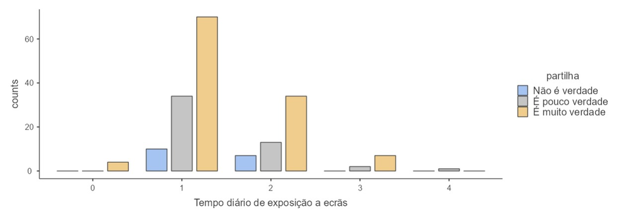

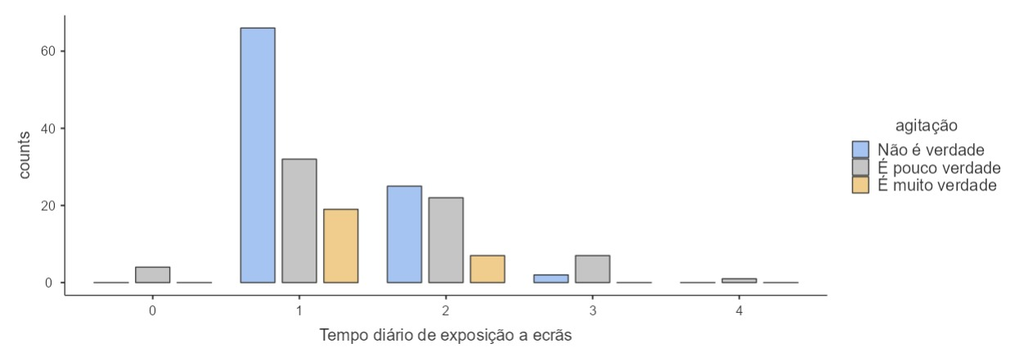

A partir de duas horas diárias de exposição a ecrãs, observa-se um aumento na agitação em comparação àqueles que não são expostos a ecrãs por esse tempo.

### Conclusão

A análise dos dados permitiu tirar conclusões relevantes acerca das características e comportamentos das crianças do 1º ciclo no Algarve.  
No que diz respeito à sensibilidade relativamente aos outros, verificámos que a maioria das crianças mostraram ser empáticas com o próximo, fruto também possivelmente do período negativo vivido no contexto pandémico. Assim, este resultado foi de encontro ao que esperávamos, uma vez que na escola existem várias interações sociais, o que contribui para a entreajuda e compreensão relativamente aos outros.  
Relativamente ao isolamento social, contrariamente ao expectável pelo facto de as aulas online terem propiciado tendências à solidão, as crianças demonstraram ter um baixo nível de isolamento, o que pode ser explicado pela necessidade de estabelecer conexões, fruto do confinamento.  
Hoje em dia as crianças têm acesso à tecnologia muito cedo, sendo que a maioria delas costuma passar elevadas horas em frente a um ecrã. Desta forma, esperaríamos que o número de horas passado pela maioria fosse superior. Os resultados obtidos possivelmente relacionam-se com o facto de os pais das crianças desta amostra controlarem o tempo que passam em frente aos ecrãs.  
Em suma, as crianças do 1º ciclo no Algarve demonstraram ser empáticas, ter um baixo nível de isolamento social e um uso moderado de tecnologia, sugerindo um panorama favorável de saúde psicológica e bem-estar pós-pandémico.